# Reconstruction d'images scannographie par réseaux neuronaux convolutifs

## Reconstruction d'Images Scannographie par Réseaux Neuronaux Convolutifs

La reconstruction d'images à partir de données de sinogrammes est une étape cruciale en imagerie médicale, permettant de visualiser les structures anatomiques internes avec précision. Traditionnellement, les algorithmes de reconstruction tels que la méthode de rétroprojection filtrée (FBP) étaient largement utilisés pour cette tâche. Cependant, l'évolution des technologies a conduit à l'exploration de nouvelles approches, notamment l'utilisation de modèles de deep learning pour cette reconstruction. Ce projet présente une exploration approfondie de l'utilisation des réseaux neuronaux convolutifs (CNN) pour la reconstruction d'images scannographiques,.

```python
import numpy as np
import matplotlib.pyplot as plt
import astra
from tensorflow.keras.models import Sequential
from tensorflow.keras.layers import Conv2D, Flatten, Dense, Reshape
from skimage.metrics import peak_signal_noise_ratio as psnr
from skimage.metrics import structural_similarity as ssim

# Générer une image de fantôme
V_exact = np.zeros((256, 256))
V_exact[100:150, 100:150] = 1.0  # Rectangle blanc au centre de l'image

# Générer des rayons X pour simuler une scannographie
angles = np.linspace(0, np.pi, 180)  # Angles de projection
proj_geom = astra.create_proj_geom('parallel', 1.0, 256, angles)
vol_geom = astra.create_vol_geom(256, 256)
proj_id = astra.create_projector('linear', proj_geom, vol_geom)
```

```python
# Créer un sinogramme simulant une scannographie
sinogram_id, sinogram = astra.create_sino(V_exact, proj_id)

# Préparer les données pour le modèle de deep learning
sinogram = sinogram.reshape(-1, 256, 180, 1)  # Adapter les dimensions pour TensorFlow
sinogram = sinogram / np.max(sinogram)  # Normaliser les données si nécessaire
```

```python
# Créer le modèle de reconstruction avec TensorFlow
model = Sequential()
model.add(Conv2D(32, (3, 3), activation='relu', input_shape=(256, 180, 1)))
model.add(Flatten())
model.add(Dense(64, activation='relu'))
model.add(Dense(256 * 256, activation='sigmoid'))
model.add(Reshape((256, 256, 1)))

# Compiler le modèle
model.compile(optimizer='adam', loss='mse')
# Entraîner le modèle avec les sinogrammes en entrée et les images d'origine en sortie
history = model.fit(sinogram, V_exact.reshape(-1, 256, 256, 1), epochs=10)
```

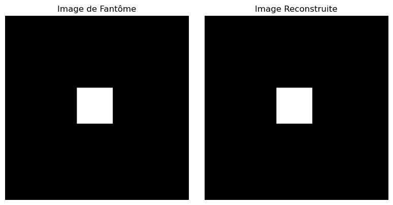

```python
# Reconstruction de l'image à partir du sinogramme test avec le modèle entraîné
reconstructed_image = model.predict(sinogram[0:1])
# Affichage de l'image reconstruite
plt.figure(figsize=(8, 4))

plt.subplot(1, 2, 1)
plt.title('Image de Fantôme')
plt.imshow(V_exact, cmap='gray')
plt.axis('off')

plt.subplot(1, 2, 2)
plt.title('Image Reconstruite')
plt.imshow(reconstructed_image.squeeze(), cmap='gray')
plt.axis('off')

plt.tight_layout()
plt.show()
```

```python
# Calcul de la PSNR et du SSIM entre l'image de fantôme et l'image reconstruite
psnr_value = psnr(V_exact, reconstructed_image.squeeze())
ssim_value = ssim(V_exact, reconstructed_image.squeeze(), data_range=reconstructed_image.max() - reconstructed_image.min())
# Affichage des résultats
print(f"Peak Signal-to-Noise Ratio (PSNR) : {psnr_value:.2f} dB")
print(f"Structural Similarity Index (SSIM) : {ssim_value:.4f}")
```

```
Peak Signal-to-Noise Ratio (PSNR) : 93.10 dB
Structural Similarity Index (SSIM) : 1.0000
```

PSNR de 93.10 dB : traduit une très faible distorsion entre l'image de référence (le fantôme) et l'image reconstruite. Ce score indique une qualité de reconstruction élevée, avec une présence minime de bruit ou d'artefacts, démontrant une fidélité remarquable dans la reconstruction.

SSIM de 1.0000 : indique une similarité structurelle maximale entre l'image de référence et l'image reconstruite. Cela signifie que chaque détail, la luminance, le contraste et la structure sont préservés dans la reconstruction, sans aucune déviation visuelle entre les deux images.

```python
# Sauvegarde du modèle
model.save('Reconstruction_image_scannographie.h5')
```

Les performances élevées évaluées par le PSNR (93.10 dB) et le SSIM (1.0000) indiquent une reconstruction quasi parfaite, caractérisée par une très faible distorsion et une similarité structurelle maximale entre l'image de référence et l'image reconstruite.